# ANOVA Assumptions and the Kruskal-Wallis - Week 5, Lecture 2

Author

Hector Gavilanes

```r
#install.packages(DescTools)
#install.packages("pgirmess")
#install.packages("ggstatsplot")
#install.packages("ISLR")
library(tidyverse)
library(gsheet)
library(formattable)
library(DescTools) # perform Dunnett, Levene Test
library(pgirmess) # perform Kruskal-Wallis Post-hoc
library(ggstatsplot)
library(ISLR)
library(patchwork)
```

**Recall the agricultural data from the ANOVA activity available in the following [Google Sheet](https://docs.google.com/spreadsheets/d/1CFyuuWy-4YmVU3wkYuC8Uf3xW3qkpCnpF468NjBAhbY/edit#gid=0).**

```r
# clear environment
rm(list = ls())

# extract data
data <- as_tibble(gsheet2tbl("https://docs.google.com/spreadsheets/d/1CFyuuWy-4YmVU3wkYuC8Uf3xW3qkpCnpF468NjBAhbY/edit#gid=0"))

# transform data
clean_data <- data %>%
  # delete empty rows
  drop_na()
# pivot to long data
long_data <- clean_data %>%
  pivot_longer(cols = c("Herbicide1", "Herbicide2", "Control"),
               names_to = "Herbicide_groups",
               values_to = "Results")

# ---Colors---
custom_gray = "#3D3D3D"
custom_green_dark = "#71CA97"
custom_green_light = "#DeF7E9"
custom_green = "#7FBD32"
custom_purple = "#700CBC"
custom_orange = "#FB8604"
custom_density_hue = c(custom_purple,custom_orange, custom_green)

# ***FUNCTIONS***
# f00 - Change default table format
change_table_format <- function(data_table){
  # local variables
  first_column <- data_table[1]
  dataframe_length <- NCOL(data_table)
  # format
  formattable(data_table, align = c("l",rep("c", dataframe_length - 1)),
              list(first_column = formatter("span", style = ~ style(color = custom_gray, font.weight = "bold"))
              )#/end list
              )#/end formattable
}
```

#### 1. State the ANOVA assumptions mathematically.

```r
# ANOVA table
module_data_anova <- aov(long_data$Results ~ long_data$Herbicide_groups)
summary(module_data_anova)
```

```
                           Df Sum Sq Mean Sq F value Pr(>F)
long_data$Herbicide_groups  2    373  186.40   3.677 0.0293 *
Residuals                  87   4410   50.69
---
Signif. codes:  0 '***' 0.001 '**' 0.01 '*' 0.05 '.' 0.1 ' ' 1
```

```r
# Summary table
sd_table <- long_data %>%
  drop_na() %>%
  group_by(Herbicide_groups) %>%
  summarise(sd(Results)) %>%
  ungroup()
change_table_format(sd_table)
```

| Herbicide_groups | sd(Results) |
| --- | --- |
| Control | 7.378192 |
| Herbicide1 | 8.452777 |
| Herbicide2 | 5.116285 |

```r
# Levene's test for equality of variance,
# default: median, provides a more robust test (Brown-Forsythe-Test)
LeveneTest(long_data$Results ~ long_data$Herbicide_groups)
```

```
Levene's Test for Homogeneity of Variance (center = median)
      Df F value  Pr(>F)
group  2  3.1703 0.04688 *
      87
---
Signif. codes:  0 '***' 0.001 '**' 0.01 '*' 0.05 '.' 0.1 ' ' 1
```

#### 2. Explain how to check the ANOVA assumptions.

The one-way ANOVA hypothesis test indicates a difference between the groups. However, there is a need to determine which groups are different. Moreover, a residual analysis will check for the normal distribution of the data.

In this case, residual plots can be generated with QQ plots, or histograms to check visually for normality of residuals.

It is good practice to check for normality from the continuous variable because of the chances of having false positive results increase. If the assumption fails, a formal statistical test like Kruskal-Wallis is a nonparametric alternative to one-way ANOVA.

The one-way ANOVA assumptions are listed below.

Normality: The variable under discussion is regularly distributed for each population.

Sample independence: Each sample is drawn separately from the others.

Variance equality: The data variance in each group is the same.

Simple random samples: Simple random samples are samples taken from the populations under study.

#### 3. Assess the ANOVA assumptions for the agricultural data, graphically. In addition to providing the relevant graphs, you must provide an assessment for each assumption.

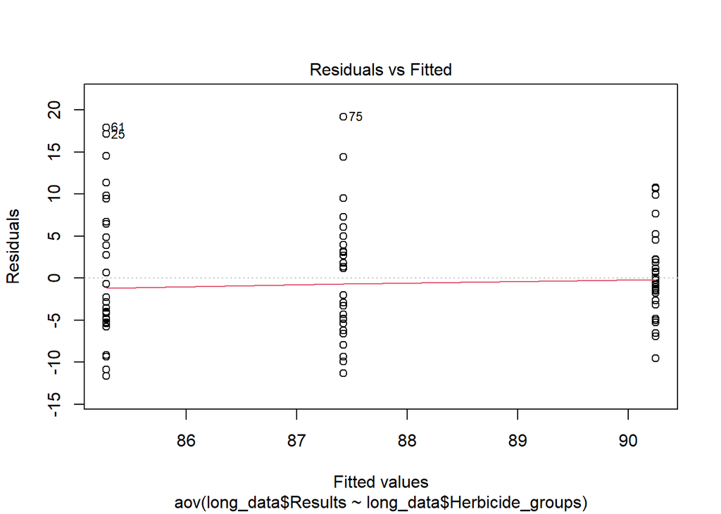

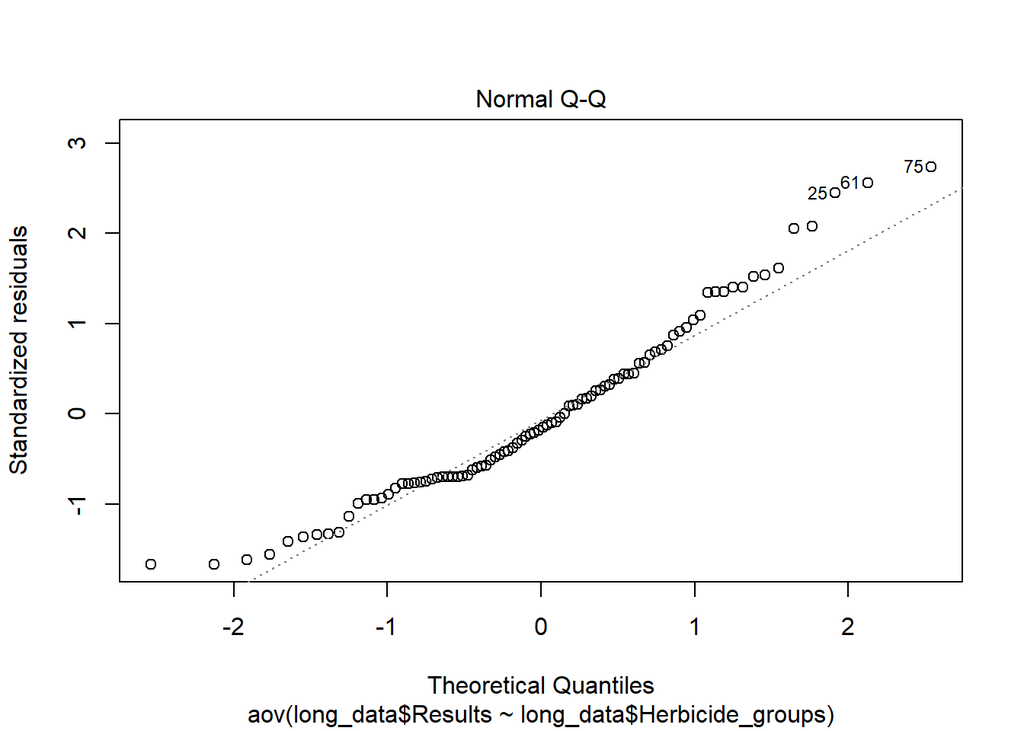

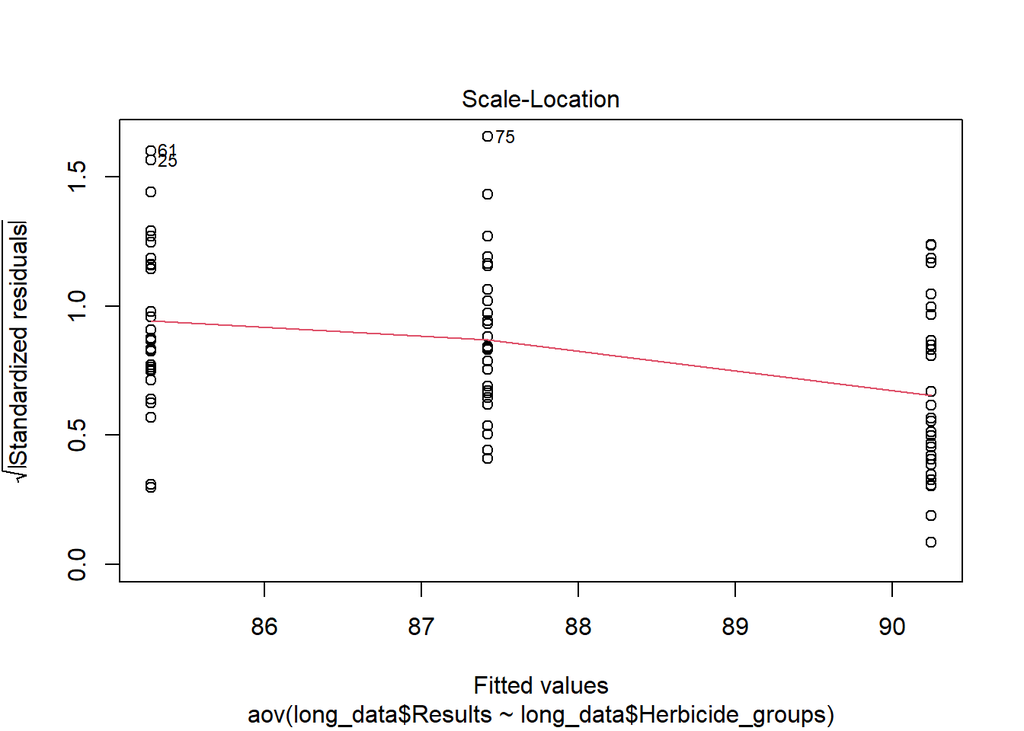

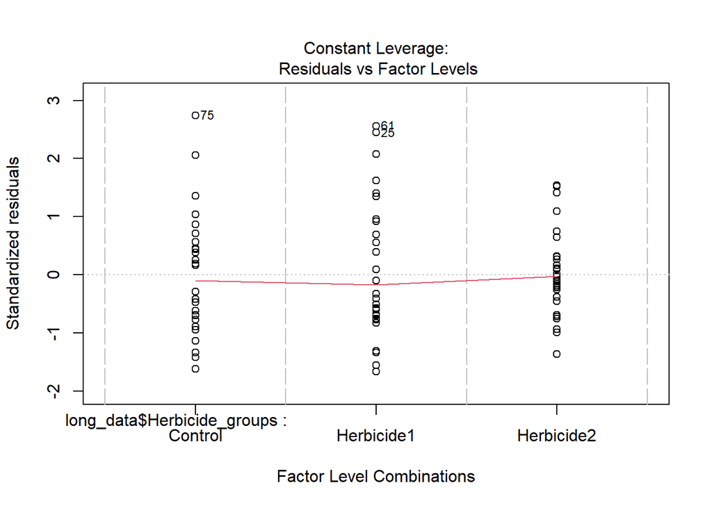

```r
plot(module_data_anova)
```

The QQ plot displays normality of residuals. There are a few outliers towards the right tail. Nonetheless, the outliers do not represent a concern.

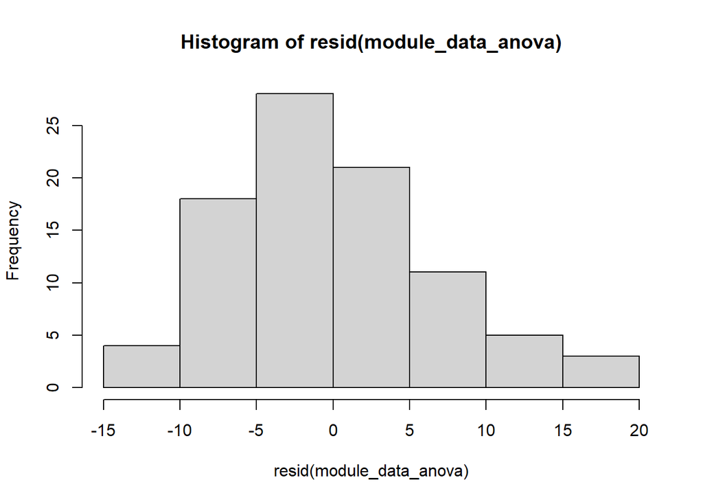

```r
# histogram
hist(resid(module_data_anova))
```

The histogram is positively skewed; however, the data is relatively normal. Thus, the graph does not represent a cause for concern.

```r
# one-way ANOVA Hypothesis test
module_data_anova <- aov(long_data$Results ~ long_data$Herbicide_groups)
summary(module_data_anova)
```

```
                           Df Sum Sq Mean Sq F value Pr(>F)
long_data$Herbicide_groups  2    373  186.40   3.677 0.0293 *
Residuals                  87   4410   50.69
---
Signif. codes:  0 '***' 0.001 '**' 0.01 '*' 0.05 '.' 0.1 ' ' 1
```

### Hypothesis

- $H_0$: $\mu Control = \mu HerbicideA\ = \mu HerbicideB$
- $H_1$: at least one group is different

### Test Statistic

- $F_0 = 3.677$

### p-Value

- $p = 0.0293$

## Conclusion

Reject $H_0$ at the $\alpha$=0.05 level. There is sufficient evidence to suggest that there is a difference in the average yield between the three groups.

#### 6. Perform the Kruskal-Wallis to determine if there is a difference between the treatment groups. Test at the $\alpha=0.05$ level.

```r
kruskal.test(long_data$Results ~ long_data$Herbicide_groups)
```

```
    Kruskal-Wallis rank sum test

data:  long_data$Results by long_data$Herbicide_groups
Kruskal-Wallis chi-squared = 8.6303, df = 2, p-value = 0.01336
```

### Hypothesis: Kruskal-Wallis

- $H_0$: $M_{Control} = M_A = M_B$
- $H_1$: at least one group is different

### Test Statistic

- $H = 8.6303$

### p-Value

- $p = 0.01336$

## Conclusion

Reject $H_0$ at the $\alpha$=0.05 level. There is sufficient evidence to suggest that there is a difference in the average yield between the three groups.

#### 7. Perform the Kruskal-Wallis post-hoc test to determine what differences exist between groups. Test at the $\alpha=0.05$ level.

```r
# Kruskal-Wallis post-hoc
kruskalmc(long_data$Results ~ long_data$Herbicide_groups)
```

```
Multiple comparison test after Kruskal-Wallis
p.value: 0.05
Comparisons
                        obs.dif critical.dif difference
Control-Herbicide1     8.316667     16.14828      FALSE
Control-Herbicide2    11.416667     16.14828      FALSE
Herbicide1-Herbicide2 19.733333     16.14828       TRUE
```

- Only Herbicide A and B are significant different.

ANOVA and Kruskal-Wallis tests led to the same conclusion.

#### 8. Challenge! Construct a graph (or multiple graphs) to aid in explaining this to the agricultural researcher.

The following QQ plot displays how the values lie on the 45 degree line relatively well. The data is approximately normally distributed.

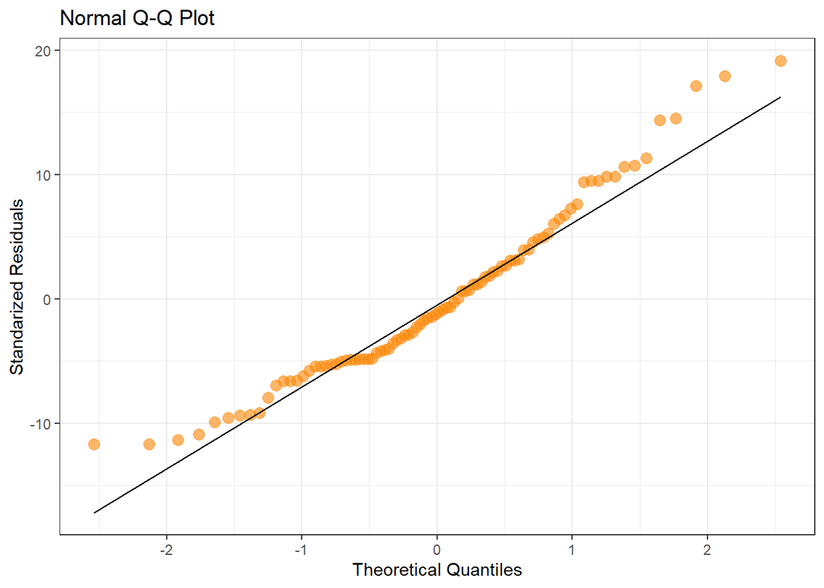

```r
# QQ plot
ggplot(module_data_anova, aes(sample = module_data_anova$residuals))+
  geom_qq(size=3, alpha = 0.6, color = custom_orange)+
  geom_qq_line()+
  theme_bw() +
  labs(title = "Normal Q-Q Plot")+
  xlab("Theoretical Quantiles") +
  ylab("Standarized Residuals")
```

The histogram quickly match the general appearance of a normal distribution. The data is skewed; nonetheless, it does not represent a cause for concern.

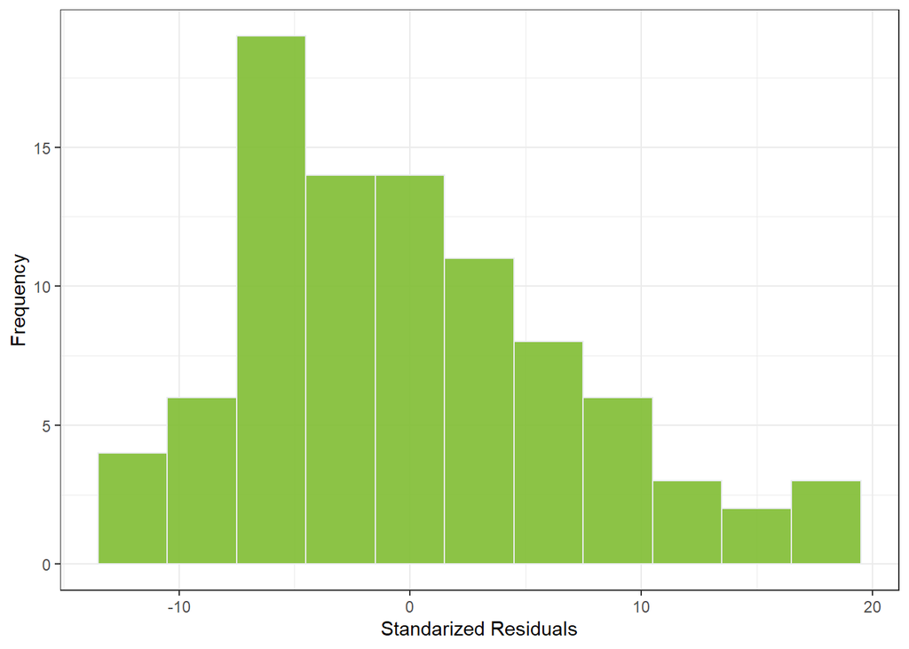

```r
# histogram
ggplot(lm(long_data$Results ~ long_data$Herbicide_groups)) +
  geom_histogram(aes(x=module_data_anova$residuals),
                 binwidth=3, fill=custom_green, color="#e9ecef", alpha=0.9)+
  xlab("Standarized Residuals")+
  ylab("Frequency")+
  theme_bw()
```

The graph below shows the fitted vs residuals. The plot is used to detect non-linearity, unequal error variances, and outliers.

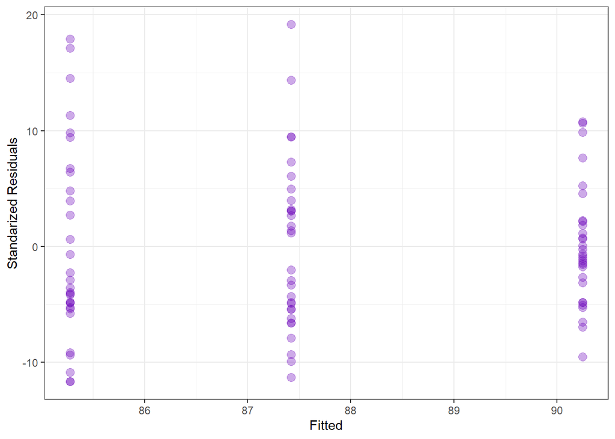

```r
# fitted vs residuals
ggplot(lm(long_data$Results ~ long_data$Herbicide_groups)) +
  geom_point(aes(x=.fitted, y=.resid),
             size=3, alpha = 0.35, color = custom_purple)+
  xlab("Fitted")+
  ylab("Standarized Residuals")+
  theme_bw()
```

The following density graph displays the variance among the three groups.

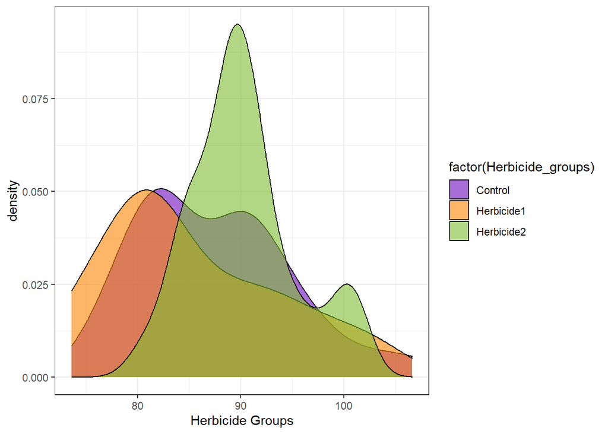

```r
# density plot
density_plot <- long_data %>%
  ggplot(aes(Results, fill = factor(Herbicide_groups)))+
  geom_density(alpha = 0.6)+
  xlab("Herbicide Groups")+
  theme_bw()+
  scale_fill_manual(values = custom_density_hue)+
  scale_color_manual(values = custom_density_hue)
density_plot
```

The following chart displays all three groups with a significant difference outlined between Herbicide A and B. The Bonferroni correction is used to reduce the chances of obtaining false-positive results.

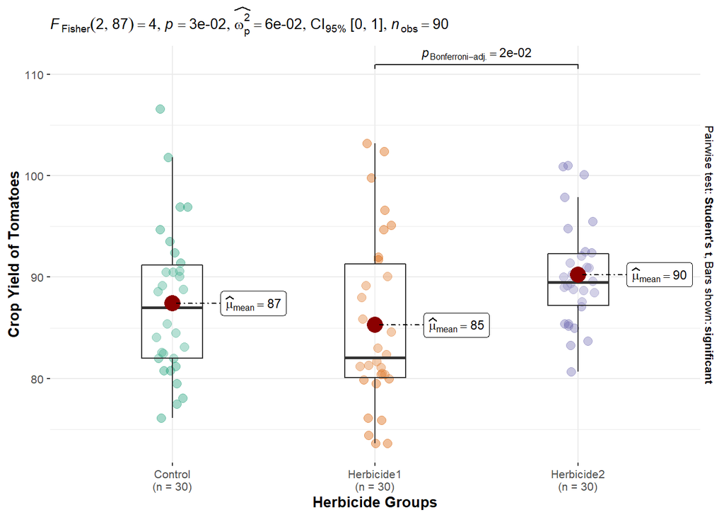

```r
ggbetweenstats(
  data = long_data,
  x = Herbicide_groups,
  y = Results,
  plot.type = "box",
  type = "p",
  pairwise.display = "s",
  var.equal = T,
  p.adjust.method = "bonferroni",
  ylab = "Crop Yield of Tomatoes",
  xlab = "Herbicide Groups",
  k = 0,
  bf.message = F
)
```